# Dataset Analysis with Kernel Regression

```r
str(Bejaia.dataset)
```

```
## 'data.frame':    122 obs. of  11 variables:
##  $ Temperature: int  29 29 26 25 27 31 33 30 25 28 ...
##  $ RH         : int  57 61 82 89 77 67 54 73 88 79 ...
##  $ Ws         : int  18 13 22 13 16 14 13 15 13 12 ...
##  $ Rain       : num  0 1.3 13.1 2.5 0 0 0 0 0.2 0 ...
##  $ FFMC       : num  65.7 64.4 47.1 28.6 64.8 82.6 88.2 86.6 52.9 73.2 ...
##  $ DMC        : num  3.4 4.1 2.5 1.3 3 5.8 9.9 12.1 7.9 9.5 ...
##  $ DC         : num  7.6 7.6 7.1 6.9 14.2 22.2 30.5 38.3 38.8 46.3 ...
##  $ ISI        : num  1.3 1 0.3 0 1.2 3.1 6.4 5.6 0.4 1.3 ...
##  $ BUI        : num  3.4 3.9 2.7 1.7 3.9 7 10.9 13.5 10.5 12.6 ...
##  $ FWI        : num  0.5 0.4 0.1 0 0.5 2.5 7.2 7.1 0.3 0.9 ...
##  $ Classes    : int  0 0 0 0 0 1 1 1 0 0 ...
```

```r
Bejaia.dataset$Classes <-as.factor(Bejaia.dataset$Classes)


Bejaia.dataset$Temperature <- as.numeric(Bejaia.dataset$Temperature)
Bejaia.dataset$RH <- as.numeric(Bejaia.dataset$RH)
Bejaia.dataset$Ws <- as.numeric(Bejaia.dataset$Ws)
Bejaia.dataset$Classes <- factor(Bejaia.dataset$Classes, levels = c(0,1))

#install.packages('e1071')
library(e1071)
#install.packages("dplyr")
library(dplyr)
```

```r
library(ggplot2)
#install.packages("caTools")
library(caTools)

#splitting into training and testing sets
set.seed(123)
split <- sample.split(Bejaia.dataset$Classes, SplitRatio = 0.75)
Bejaia_Train <- subset(Bejaia.dataset, split == TRUE)
Bejaia_Test <- subset(Bejaia.dataset, split = FALSE)
#Feature Scaling

Bejaia_Train[-11] <- scale(Bejaia_Train[-11])
Bejaia_Test[-11] <- scale(Bejaia_Test[-11])

#Fitting SVM to the Training set

#linear
svmModelTuning.out.linear <- tune(svm, Classes~., data = Bejaia.dataset,
                                        kernel = "linear", ranges = list(cost = c(0.001, 0.01, 0.1, 1, 5, 10, 100)),scale=TRUE)
svmModel.linear <- svmModelTuning.out.linear$best.model
svmModel.linear
```

```
##
## Call:
## best.tune(METHOD = svm, train.x = Classes ~ ., data = Bejaia.dataset,
##     ranges = list(cost = c(0.001, 0.01, 0.1, 1, 5, 10, 100)), kernel = "linear",
##     scale = TRUE)
##
##
## Parameters:
##    SVM-Type:  C-classification
##  SVM-Kernel:  linear
##        cost:  5
##
## Number of Support Vectors:  14
```

```r
#radial
svmModelTuning.out.radial <- tune(svm, Classes~., data = Bejaia.dataset,
                                 kernel = "radial", ranges = list(cost = c(0.001, 0.01, 0.1, 1, 5, 10, 100)),scale=TRUE)
svmModel.radial <- svmModelTuning.out.radial$best.model
svmModel.radial
```

```
##
## Call:
## best.tune(METHOD = svm, train.x = Classes ~ ., data = Bejaia.dataset,
##     ranges = list(cost = c(0.001, 0.01, 0.1, 1, 5, 10, 100)), kernel = "radial",
##     scale = TRUE)
##
##
## Parameters:
##    SVM-Type:  C-classification
##  SVM-Kernel:  radial
##        cost:  100
##
## Number of Support Vectors:  23
```

```r
#polynomial

svmModelTuning.out.polynomial <- tune(svm, Classes~., data = Bejaia.dataset,
                                        kernel = "polynomial", ranges = list(cost = c(0.001, 0.01, 0.1, 1, 5, 10, 100)),scale=TRUE)
svmModel.polynomial <- svmModelTuning.out.polynomial$best.model
svmModel.polynomial
```

```
##
## Call:
## best.tune(METHOD = svm, train.x = Classes ~ ., data = Bejaia.dataset,
##     ranges = list(cost = c(0.001, 0.01, 0.1, 1, 5, 10, 100)), kernel = "polynomial",
##     scale = TRUE)
##
##
## Parameters:
##    SVM-Type:  C-classification
##  SVM-Kernel:  polynomial
##        cost:  1
##      degree:  3
##      coef.0:  0
##
## Number of Support Vectors:  69
```

```r
#sigmoid

svmModelTuning.out.sigmoid <- tune(svm, Classes~., data = Bejaia.dataset,
                                            kernel = "sigmoid", ranges = list(cost = c(0.001, 0.01, 0.1, 1, 5, 10, 100)),scale=TRUE)
svmModel.sigmoid <- svmModelTuning.out.sigmoid$best.model
svmModel.sigmoid
```

```
##
## Call:
## best.tune(METHOD = svm, train.x = Classes ~ ., data = Bejaia.dataset,
##     ranges = list(cost = c(0.001, 0.01, 0.1, 1, 5, 10, 100)), kernel = "sigmoid",
##     scale = TRUE)
##
##
## Parameters:
##    SVM-Type:  C-classification
##  SVM-Kernel:  sigmoid
##        cost:  1
##      coef.0:  0
##
## Number of Support Vectors:  35
```

```r
#Predicted Values

predictedvalues.linear <- predict(svmModel.linear, newdata = Bejaia_Test[-11])
predictedvalues.radial <- predict(svmModel.radial, newdata = Bejaia_Test[-11])
predictedvalues.polynomial <- predict(svmModel.polynomial, newdata = Bejaia_Test[-11])
predictedvalues.sigmoid <- predict(svmModel.sigmoid, newdata = Bejaia_Test[-11])

#Confusion Matrix

cm.linear <- table(Bejaia_Test[,11],predictedvalues.linear)
cm.linear
```

```
##    predictedvalues.linear
##      0  1
##   0 63  0
##   1 59  0
```

```r
cm.radial <- table(Bejaia_Test[,11],predictedvalues.radial)
cm.radial
```

```
##    predictedvalues.radial
##      0  1
##   0 63  0
##   1 59  0
```

```r
cm.polynomial <- table(Bejaia_Test[,11],predictedvalues.polynomial)
cm.polynomial
```

```
##    predictedvalues.polynomial
##      0  1
##   0 63  0
##   1 59  0
```

```r
cm.sigmoid <- table(Bejaia_Test[,11],predictedvalues.sigmoid)
cm.sigmoid
```

```
##    predictedvalues.sigmoid
##      0  1
##   0 63  0
##   1 59  0
```

## Statistical Modeling

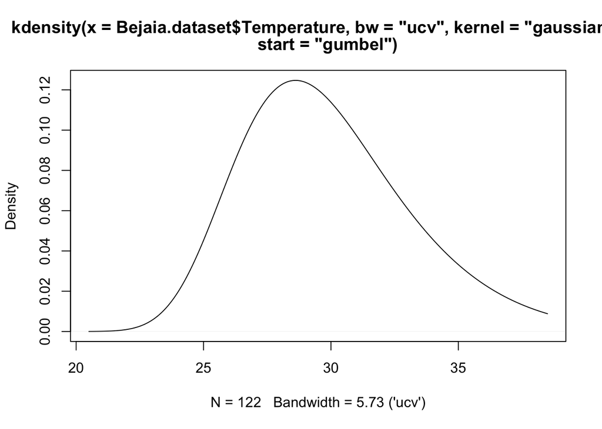

```r
#visualization of training set results is only possible with two explanatory variables




#bandwidths example
library(ggplot2)
#install.packages("kdensity")
library(kdensity)


#unbiased cross validation
kde = kdensity(Bejaia.dataset$Temperature,bw = "ucv", start = "gumbel",kernel = "gaussian" )
plot(kde)
```

```r
#compare to using other bandwidths (h)
```

#### Cars

```r
# Cars Example

library(PLRModels)

#examine the data
data(cars)

#find optimal bandwidth with np.gcv function (cross validation)
Cars <- data.matrix(cars)
Cars.optimalvalue <- np.gcv(data = Cars, h.seq=NULL, num.h = 50, estimator = "NW",
       kernel = "gaussian")
Cars.optimalvalue$h.opt
```

```
## [1] 5.928571
```

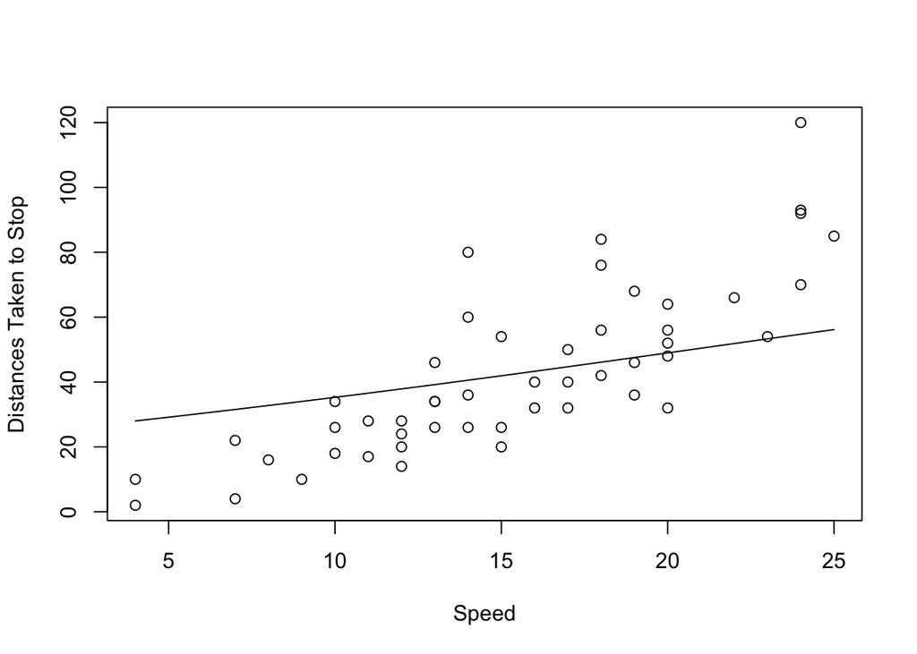

```r
# R code to analyze the simulated (X,Y) data
# using nonparametric kernel regression

# First look at a scatter plot of Y against X:

plot(cars$speed, cars$dist,
     xlab = "Speed", ylab = "Distances Taken to Stop")



# There appears to be a relationship between Y and X, but it is
# not a linear relationship

########## Kernel Regression Estimation ######################


# The ksmooth() function in R offers the
# Nadaraya-Watson kernel regression estimator
# with the choice of "normal" or "box" (uniform) kernels.

# Using the kernel regression estimator
# with a relatively large bandwidth:

nonpar.reg.largebw <- ksmooth(cars$speed, cars$dist, kernel="normal", bandwidth=20)

# Plotting the large bandwidth estimated curve on top of the data:

plot(cars$speed, cars$dist,
     xlab = "Speed", ylab = "Distances Taken to Stop"); lines(nonpar.reg.largebw)
```

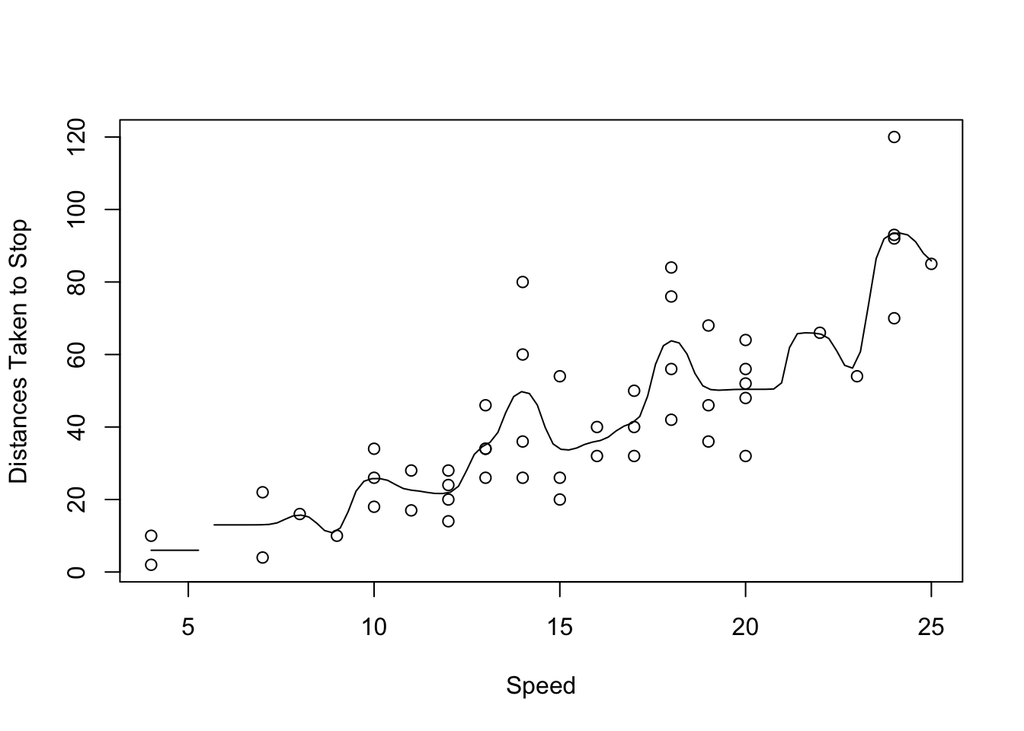

```r
# Using the kernel regression estimator
# with a relatively small bandwidth:

nonpar.reg.smallbw <- ksmooth(cars$speed, cars$dist, kernel="normal", bandwidth=1)

# Plotting small bandwidth estimated curve on top of the data:

plot(cars$speed, cars$dist,
     xlab = "Speed", ylab = "Distances Taken to Stop");lines(nonpar.reg.smallbw)
```

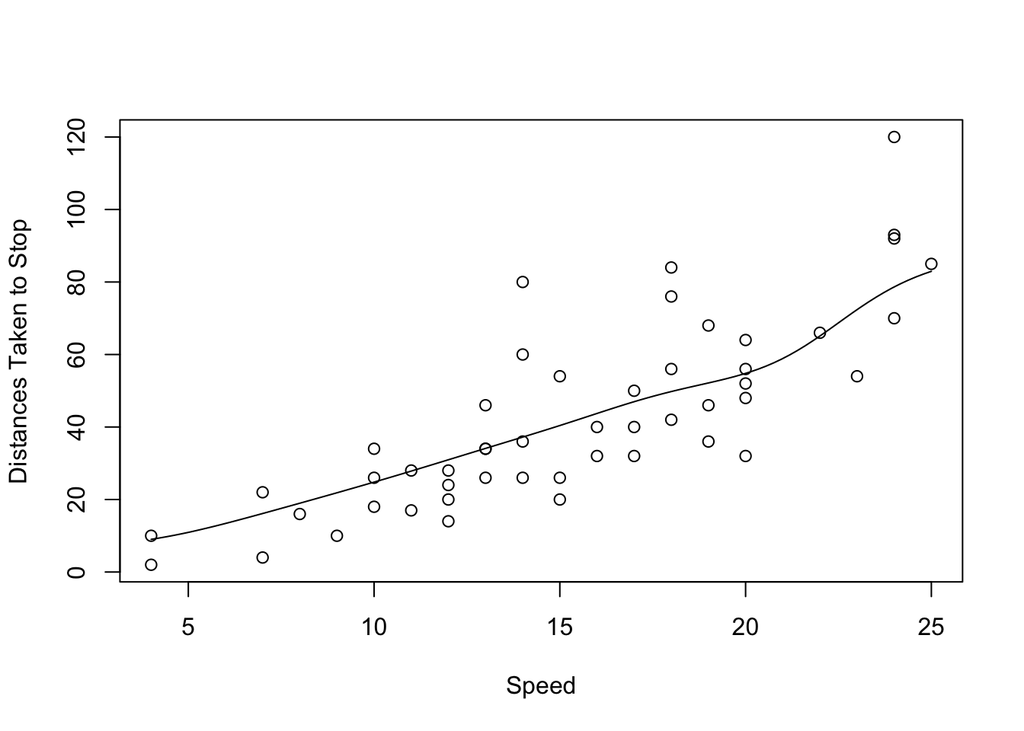

```r
# Using the kernel regression estimator
# with the optimal bandwidth of 5.928571

nonpar.reg.optimal <- ksmooth(cars$speed, cars$dist, kernel="normal", bandwidth=5.928571)

#plot optimal bandwidth estimated curve on top of the data:

plot(cars$speed, cars$dist,
     xlab = "Speed", ylab = "Distances Taken to Stop");lines(nonpar.reg.optimal)
```

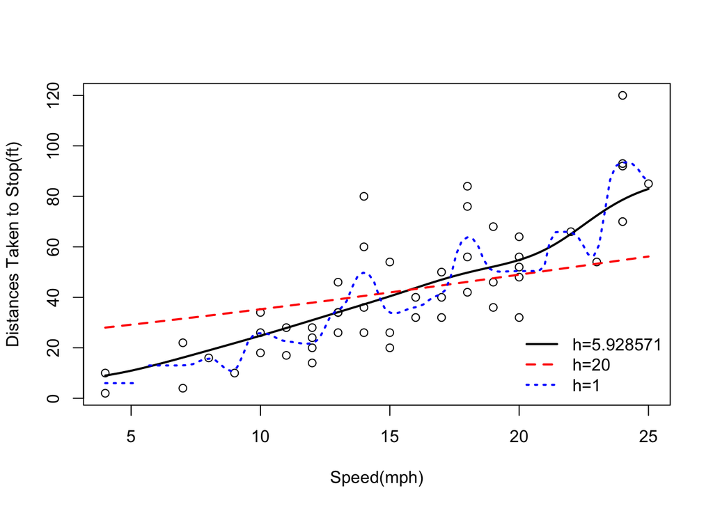

```r
#plot all three bandwidths together for comparison

plot(cars$speed, cars$dist,
     xlab = "Speed(mph)", ylab = "Distances Taken to Stop(ft)")
lines(nonpar.reg.optimal, lwd = 2)
lines(nonpar.reg.largebw, lwd = 2, lty = 2, col = "red")
lines(nonpar.reg.smallbw, lwd = 2, lty = 3, col = "blue")
legend("bottomright", c("h=5.928571", "h=20", "h=1"),
       lty = 1:3, lwd = 2, col = c("black", "red", "blue"), bty = "n")
```

## References

Awad, M., & Khanna, R. (2015). Support vector machines for classification. In *Efficient learning machines* (pp. 39-66). Apress, Berkeley, CA.

Dudek, G., & Pelka, P. (2017, May). Medium-term electric energy demand forecasting using Nadaraya- Watson estimator. In *2017 18th International Scientific Conference on Electric Power Engineering*

Demir, S., & Toktamiş, Ö. (2010). On the adaptive Nadaraya-Watson kernel regression estimators. Hacettepe Journal of Mathematics and Statistics, 39(3), 429-437.

Dua, D. and Graff, C. (2019). UCI Machine Learning Repository [http://archive.ics.uci.edu/ml]. Irvine, CA: University of California, School of Information and Computer Science.

Blundell, R., & Duncan, A. (1998). Kernel regression in empirical microeconomics. *Journal of Human Resources*, 62-87.

Ezekiel, M. (1930) Methods of Correlation Analysis. Wiley.

Wainer, J., & Cawley, G. (2017). Empirical evaluation of resampling procedures for optimising SVM hyperparameters. *Journal of Machine Learning Research*, 18(15), 1-35.

Vidvan, T. (2020, March 13). SVM Kernel Functions - 'SVM knowledge. Retrieved from TechVidvan website: https://techvidvan.com/tutorials/svm-kernel-functions/

Heiwig, N.(2021). Nonparametric Regression (Smoothers) in R. Department of Psychology & School of Statistics University of Minnesota.

Karatzoglou, A., Meyer, D., & Hornik, K. (2006). Support Vector Machines inR. Journal of Statistical Software, 15(9). https://doi.org/10.18637/jss.v015.i09

Kauermann, G., & Opsomer, J. D. (2004). Generalized cross-validation for bandwidth selection of backfitting estimates in generalized additive models. Journal of Computational and Graphical Statistics, 13(1), 66-89.